# Finding the Key Using TRACES Sampled from Real Machines CPA

```python
import csv,os
import numpy as np
from scipy import stats
import matplotlib.pyplot as plt
import pandas as pd
from IPython.display import display, Markdown, Latex
```

For this part we use real traces which were taken from FPGA which performed encryption using AES The database for all samples at the time of the last round can be found in the file `"_DATA1_keyset_9_attack.csv"`

```python
KEYSET_FILE_PATH  = "./Resources/_DATA1_keyset_9_attack.csv"
CPA_HW_OUT_PATH = "./Resources/CPA_HW_Ex_Sample.dat"
CPA_Shifted_HW_OUT_PATH = "./Resources/CPA_HW_Shifted_Sample.dat"
CPA_Plot_PATH = "./Resources/CPA_AllKeyByte_N"
CPA_BOOK_RES_PATH = "./Resources/CPA_BOOK_RES.dat"
COR_TABLE_PATH = "./Resources/correlation_table.dat"
CPA_Book_Result_PATH = "./Resources/CPA_Book_Result.dat"
```

To save calculations in real time, we saved intermediate results files above. You can delete them and run again.

```python
wstart = 10
wstop = 1999
wlen = wstop-wstart
InvSbox = (
    0x52, 0x09, 0x6A, 0xD5, 0x30, 0x36, 0xA5, 0x38, 0xBF, 0x40, 0xA3, 0x9E, 0x81, 0xF3, 0xD7, 0xFB,
    0x7C, 0xE3, 0x39, 0x82, 0x9B, 0x2F, 0xFF, 0x87, 0x34, 0x8E, 0x43, 0x44, 0xC4, 0xDE, 0xE9, 0xCB,
    0x54, 0x7B, 0x94, 0x32, 0xA6, 0xC2, 0x23, 0x3D, 0xEE, 0x4C, 0x95, 0x0B, 0x42, 0xFA, 0xC3, 0x4E,
    0x08, 0x2E, 0xA1, 0x66, 0x28, 0xD9, 0x24, 0xB2, 0x76, 0x5B, 0xA2, 0x49, 0x6D, 0x8B, 0xD1, 0x25,
    0x72, 0xF8, 0xF6, 0x64, 0x86, 0x68, 0x98, 0x16, 0xD4, 0xA4, 0x5C, 0xCC, 0x5D, 0x65, 0xB6, 0x92,
    0x6C, 0x70, 0x48, 0x50, 0xFD, 0xED, 0xB9, 0xDA, 0x5E, 0x15, 0x46, 0x57, 0xA7, 0x8D, 0x9D, 0x84,
    0x90, 0xD8, 0xAB, 0x00, 0x8C, 0xBC, 0xD3, 0x0A, 0xF7, 0xE4, 0x58, 0x05, 0xB8, 0xB3, 0x45, 0x06,
    0xD0, 0x2C, 0x1E, 0x8F, 0xCA, 0x3F, 0x0F, 0x02, 0xC1, 0xAF, 0xBD, 0x03, 0x01, 0x13, 0x8A, 0x6B,
    0x3A, 0x91, 0x11, 0x41, 0x4F, 0x67, 0xDC, 0xEA, 0x97, 0xF2, 0xCF, 0xCE, 0xF0, 0xB4, 0xE6, 0x73,
    0x96, 0xAC, 0x74, 0x22, 0xE7, 0xAD, 0x35, 0x85, 0xE2, 0xF9, 0x37, 0xE8, 0x1C, 0x75, 0xDF, 0x6E,
    0x47, 0xF1, 0x1A, 0x71, 0x1D, 0x29, 0xC5, 0x89, 0x6F, 0xB7, 0x62, 0x0E, 0xAA, 0x18, 0xBE, 0x1B,
    0xFC, 0x56, 0x3E, 0x4B, 0xC6, 0xD2, 0x79, 0x20, 0x9A, 0xDB, 0xC0, 0xFE, 0x78, 0xCD, 0x5A, 0xF4,
    0x1F, 0xDD, 0xA8, 0x33, 0x88, 0x07, 0xC7, 0x31, 0xB1, 0x12, 0x10, 0x59, 0x27, 0x80, 0xEC, 0x5F,
    0x60, 0x51, 0x7F, 0xA9, 0x19, 0xB5, 0x4A, 0x0D, 0x2D, 0xE5, 0x7A, 0x9F, 0x93, 0xC9, 0x9C, 0xEF,
    0xA0, 0xE0, 0x3B, 0x4D, 0xAE, 0x2A, 0xF5, 0xB0, 0xC8, 0xEB, 0xBB, 0x3C, 0x83, 0x53, 0x99, 0x61,
    0x17, 0x2B, 0x04, 0x7E, 0xBA, 0x77, 0xD6, 0x26, 0xE1, 0x69, 0x14, 0x63, 0x55, 0x21, 0x0C, 0x7D,
)
```

## Section 2

Perform a CPA in which you compare the model (HW) and the measurements for each Trace You must perform a CPA based on the right byte key.

The direction of the trace contains a large number of measurements. Perform the experiment for 10, 100, 500, 1000, 2000, 4000, 8000 different messages, and indicate the degree of correlation

```python
# Byte Hamming Weight Table
hamming_weight_8bit_table = np.array([
0,1,1,2,1,2,2,3,1,2,2,3,2,3,3,4,
1,2,2,3,2,3,3,4,2,3,3,4,3,4,4,5,
1,2,2,3,2,3,3,4,2,3,3,4,3,4,4,5,
2,3,3,4,3,4,4,5,3,4,4,5,4,5,5,6,
1,2,2,3,2,3,3,4,2,3,3,4,3,4,4,5,
2,3,3,4,3,4,4,5,3,4,4,5,4,5,5,6,
2,3,3,4,3,4,4,5,3,4,4,5,4,5,5,6,
3,4,4,5,4,5,5,6,4,5,5,6,5,6,6,7,
1,2,2,3,2,3,3,4,2,3,3,4,3,4,4,5,
2,3,3,4,3,4,4,5,3,4,4,5,4,5,5,6,
2,3,3,4,3,4,4,5,3,4,4,5,4,5,5,6,
3,4,4,5,4,5,5,6,4,5,5,6,5,6,6,7,
2,3,3,4,3,4,4,5,3,4,4,5,4,5,5,6,
3,4,4,5,4,5,5,6,4,5,5,6,5,6,6,7,
3,4,4,5,4,5,5,6,4,5,5,6,5,6,6,7,
4,5,5,6,5,6,6,7,5,6,6,7,6,7,7,8
], np.uint8)
```

```python
def _variance(a):
    N = len(a)
    res = np.sqrt((N * (np.inner(a, a))) - (np.sum(a)**2))
    return res

def _covariance(a, b):
    N = len(a)
    res = (N * (np.inner(a, b))) - (np.sum(a)) * (np.sum(b))
    return res

def HammingWeight(value):
    return hamming_weight_8bit_table[value]
```

```python
MASK = 2**8 - 1 # Least significant byte
number_of_traces_list = [10,100,500,1000,2000,4000,8000]
print(f"number of traces: {number_of_traces_list}")
```

```
number of traces: [10, 100, 500, 1000, 2000, 4000, 8000]
```

```python
csv_reader_data = []
with open(KEYSET_FILE_PATH) as csv_file:
        temp_csv_reader = csv.reader(csv_file, delimiter=',')
        for row in temp_csv_reader:
            csv_reader_data.append(row[:-1])
N = (len(csv_reader_data[0])-2)
print(f"Total samples:{len(csv_reader_data)} and N={N}")
```

```
Total samples:8939 and N=2000
```

```python
display(pd.DataFrame(csv_reader_data, columns=["PT","CT"] + [f"T{i}" for i in range(1,N+1)]))
```

|  | PT | CT | T1 | T2 | T3 | T4 | T5 | T6 | T7 | T8 | ... | T1991 | T1992 | T1993 | T1994 | T1995 | T1996 | T1997 | T1998 | T1999 | T2000 |
| --- | --- | --- | --- | --- | --- | --- | --- | --- | --- | --- | --- | --- | --- | --- | --- | --- | --- | --- | --- | --- | --- |
| 0 | 21A7D2BD873F22ECB0F4840E2BD69177 | D9959FDF641778A83D3D45DC3E282F5D | 116 | 114 | 115 | 115 | 114 | 114 | 114 | 114 | ... | 113 | 112 | 113 | 114 | 115 | 114 | 116 | 116 | 116 | 117 |
| 1 | C0A06A4EE3A233EE582C28FFC83ABA0D | E412BCFE4AA01B0A2D382149AD3F2906 | 116 | 116 | 116 | 116 | 116 | 116 | 116 | 116 | ... | 112 | 112 | 112 | 112 | 114 | 114 | 115 | 114 | 114 | 114 |
| 2 | 07D3580C7695EC206ACB7476E361190C | 6BB092EF6950C6B0117FE63E7FAA5C6D | 114 | 116 | 116 | 116 | 115 | 115 | 115 | 117 | ... | 114 | 112 | 112 | 112 | 112 | 114 | 114 | 114 | 113 | 116 |
| 3 | EEF08757D5D3417F73E3655A17222476 | A79DE9A553D24744FF1FD28D4DF43651 | 114 | 114 | 115 | 114 | 116 | 114 | 113 | 113 | ... | 112 | 112 | 114 | 115 | 115 | 116 | 114 | 116 | 117 | 117 |
| 4 | 397707577D85012BB34AE3182EBD0BF6 | D2133DDCE3CC67928A084F20A2102E77 | 114 | 115 | 116 | 115 | 117 | 115 | 115 | 116 | ... | 113 | 112 | 112 | 112 | 112 | 113 | 114 | 114 | 116 | 115 |
| ... | ... | ... | ... | ... | ... | ... | ... | ... | ... | ... | ... | ... | ... | ... | ... | ... | ... | ... | ... | ... | ... |
| 8934 | 3B3684904B9F0ECA079AA1E8BEF1E447 | 999808DE26928EC8FE7A056F8321CE61 | 115 | 116 | 116 | 117 | 117 | 115 | 116 | 116 | ... | 112 | 112 | 113 | 112 | 113 | 113 | 113 | 114 | 114 | 115 |
| 8935 | D1500312A4781FBAF220D605BCD8848D | 143563446FFB99FC145E90370C7732E6 | 115 | 117 | 115 | 116 | 116 | 116 | 116 | 116 | ... | 113 | 113 | 112 | 112 | 113 | 114 | 116 | 115 | 115 | 116 |
| 8936 | 8C88E806D1A495630494FA0BE0E14E31 | 15A46DFB62A25F463ECA8A4E8F9291E4 | 116 | 117 | 118 | 117 | 116 | 116 | 115 | 116 | ... | 112 | 112 | 112 | 112 | 113 | 113 | 113 | 115 | 115 | 116 |
| 8937 | ABAA5DBDB09170C216CA9D2BC8080E2F | FA7C3ABF50C13DB1B9E3E6BDE56BAF84 | 115 | 115 | 115 | 114 | 115 | 115 | 114 | 116 | ... | 114 | 114 | 113 | 114 | 113 | 114 | 114 | 114 | 114 | 115 |
| 8938 | 15135C3508DD752CBBA00D0F7D14D911 | 990DCC7D385EAF77112F4AF324AF46EE | 116 | 116 | 117 | 117 | 117 | 115 | 115 | 115 | ... | 112 | 113 | 112 | 113 | 114 | 115 | 115 | 116 | 117 | 117 |

8939 rows × 2002 columns

Also in this part we will assume that we want to decipher the right bute of the key. Therefore, we will do the following:

**For each possible key value, and for CT, calculate the power estimate that was generated at the end of round-9 using HW**:

```python
hamming_prediction_table = np.zeros((256,len(csv_reader_data)))
if os.path.exists(CPA_HW_OUT_PATH):
    with open(CPA_HW_OUT_PATH,"r") as fp:
        for KeyGuess,line in enumerate(fp):
            hamming_prediction_table[KeyGuess] = line.split()
    print("HW computation Complete")
else:
    with open(CPA_HW_OUT_PATH,"w") as fp:
        for kb in range(0,256,1):
            csv_reader = csv_reader_data
            for idx, row in enumerate(csv_reader):
                ct_temp=int(row[1],16) & MASK
                BIT_MASK = 2**0
                r9_temp = InvSbox[ct_temp ^ kb]
                hamming_prediction_table[kb][idx] = HammingWeight(r9_temp)
            fp.write(' '.join(map(str, hamming_prediction_table[kb])) + "\n")
    print("HW computation Complete")
```

```
HW computation Complete
```

Similarly considered for each possible key value, and CT, the power estimate generated at the end of round 9 using HW when we consider the operation **shift rows**:

```python
def rotate(word, n):
    return word[n:]+word[0:n]

def shiftRowsInv(str_state):
    state = [str_state[i:i+2] for i in range(0,len(str_state), 2)]
    for i in range(4):
        state[i*4:i*4+4] = rotate(state[i*4:i*4+4],-i)
    return ''.join(map(str, state))
```

```python
shifted_hamming_prediction_table = np.zeros((256,len(csv_reader_data)))
if os.path.exists(CPA_Shifted_HW_OUT_PATH):
    with open(CPA_Shifted_HW_OUT_PATH,"r") as fp:
        for KeyGuess,line in enumerate(fp):
            shifted_hamming_prediction_table[KeyGuess] = line.split()
    print("Shifted HW computation Complete")
else:
    with open(CPA_Shifted_HW_OUT_PATH,"w") as fp:
        for kb in range(0,256,1):
            csv_reader = csv_reader_data
            for idx, row in enumerate(csv_reader):
                shifted = shiftRowsInv(row[1])
                ct = int(shifted,16)
                ct_temp=ct & MASK
                BIT_MASK = 2**0
                r9_temp = InvSbox[ct_temp ^ kb]
                shifted_hamming_prediction_table[kb][idx] = HammingWeight(r9_temp)
            fp.write(' '.join(map(str, shifted_hamming_prediction_table[kb])) + "\n")
    print("Shifted HW computation Complete")
```

```
Shifted HW computation Complete
```

```python
display(pd.DataFrame(hamming_prediction_table.transpose()))
display(pd.DataFrame(shifted_hamming_prediction_table.transpose()))
```

|  | 0 | 1 | 2 | 3 | 4 | 5 | 6 | 7 | 8 | 9 | ... | 246 | 247 | 248 | 249 | 250 | 251 | 252 | 253 | 254 | 255 |
| --- | --- | --- | --- | --- | --- | --- | --- | --- | --- | --- | --- | --- | --- | --- | --- | --- | --- | --- | --- | --- | --- |
| 0 | 4.0 | 5.0 | 2.0 | 5.0 | 3.0 | 5.0 | 5.0 | 3.0 | 6.0 | 7.0 | ... | 3.0 | 3.0 | 3.0 | 4.0 | 3.0 | 4.0 | 5.0 | 4.0 | 4.0 | 3.0 |
| 1 | 4.0 | 3.0 | 2.0 | 4.0 | 4.0 | 5.0 | 3.0 | 2.0 | 6.0 | 7.0 | ... | 4.0 | 4.0 | 2.0 | 6.0 | 4.0 | 2.0 | 2.0 | 4.0 | 4.0 | 4.0 |
| 2 | 5.0 | 4.0 | 2.0 | 3.0 | 4.0 | 7.0 | 2.0 | 3.0 | 5.0 | 3.0 | ... | 4.0 | 5.0 | 5.0 | 6.0 | 3.0 | 4.0 | 4.0 | 4.0 | 2.0 | 4.0 |
| 3 | 3.0 | 4.0 | 2.0 | 2.0 | 6.0 | 7.0 | 5.0 | 5.0 | 3.0 | 5.0 | ... | 3.0 | 4.0 | 6.0 | 6.0 | 3.0 | 3.0 | 2.0 | 4.0 | 4.0 | 6.0 |
| 4 | 1.0 | 4.0 | 6.0 | 4.0 | 5.0 | 4.0 | 3.0 | 3.0 | 5.0 | 3.0 | ... | 3.0 | 4.0 | 5.0 | 5.0 | 4.0 | 4.0 | 5.0 | 6.0 | 5.0 | 5.0 |
| ... | ... | ... | ... | ... | ... | ... | ... | ... | ... | ... | ... | ... | ... | ... | ... | ... | ... | ... | ... | ... | ... |
| 8934 | 4.0 | 2.0 | 0.0 | 5.0 | 5.0 | 3.0 | 2.0 | 5.0 | 4.0 | 7.0 | ... | 3.0 | 4.0 | 6.0 | 4.0 | 4.0 | 5.0 | 5.0 | 3.0 | 5.0 | 7.0 |
| 8935 | 6.0 | 3.0 | 5.0 | 3.0 | 5.0 | 4.0 | 2.0 | 3.0 | 4.0 | 3.0 | ... | 5.0 | 5.0 | 5.0 | 5.0 | 3.0 | 6.0 | 3.0 | 2.0 | 3.0 | 4.0 |
| 8936 | 5.0 | 3.0 | 6.0 | 3.0 | 2.0 | 3.0 | 5.0 | 4.0 | 3.0 | 4.0 | ... | 4.0 | 2.0 | 3.0 | 6.0 | 5.0 | 5.0 | 3.0 | 4.0 | 3.0 | 2.0 |
| 8937 | 5.0 | 5.0 | 5.0 | 5.0 | 4.0 | 3.0 | 2.0 | 2.0 | 4.0 | 4.0 | ... | 4.0 | 5.0 | 1.0 | 3.0 | 3.0 | 5.0 | 3.0 | 6.0 | 6.0 | 2.0 |
| 8938 | 4.0 | 3.0 | 3.0 | 4.0 | 6.0 | 4.0 | 3.0 | 6.0 | 6.0 | 3.0 | ... | 3.0 | 4.0 | 8.0 | 4.0 | 5.0 | 5.0 | 4.0 | 2.0 | 5.0 | 5.0 |

8939 rows × 256 columns

|  | 0 | 1 | 2 | 3 | 4 | 5 | 6 | 7 | 8 | 9 | ... | 246 | 247 | 248 | 249 | 250 | 251 | 252 | 253 | 254 | 255 |
| --- | --- | --- | --- | --- | --- | --- | --- | --- | --- | --- | --- | --- | --- | --- | --- | --- | --- | --- | --- | --- | --- |
| 0 | 4.0 | 3.0 | 5.0 | 4.0 | 3.0 | 3.0 | 5.0 | 5.0 | 2.0 | 4.0 | ... | 4.0 | 2.0 | 5.0 | 3.0 | 2.0 | 3.0 | 3.0 | 4.0 | 5.0 | 6.0 |
| 1 | 2.0 | 4.0 | 4.0 | 6.0 | 6.0 | 6.0 | 3.0 | 3.0 | 3.0 | 4.0 | ... | 5.0 | 3.0 | 6.0 | 7.0 | 5.0 | 5.0 | 3.0 | 4.0 | 2.0 | 2.0 |
| 2 | 5.0 | 3.0 | 3.0 | 1.0 | 2.0 | 6.0 | 6.0 | 3.0 | 1.0 | 4.0 | ... | 5.0 | 5.0 | 5.0 | 5.0 | 5.0 | 5.0 | 2.0 | 2.0 | 3.0 | 4.0 |
| 3 | 4.0 | 5.0 | 3.0 | 5.0 | 3.0 | 4.0 | 4.0 | 4.0 | 3.0 | 3.0 | ... | 7.0 | 2.0 | 4.0 | 4.0 | 1.0 | 5.0 | 4.0 | 6.0 | 4.0 | 5.0 |
| 4 | 3.0 | 4.0 | 4.0 | 5.0 | 4.0 | 3.0 | 4.0 | 3.0 | 3.0 | 3.0 | ... | 7.0 | 6.0 | 3.0 | 5.0 | 5.0 | 3.0 | 5.0 | 2.0 | 5.0 | 4.0 |
| ... | ... | ... | ... | ... | ... | ... | ... | ... | ... | ... | ... | ... | ... | ... | ... | ... | ... | ... | ... | ... | ... |
| 8934 | 2.0 | 2.0 | 3.0 | 4.0 | 5.0 | 5.0 | 5.0 | 5.0 | 5.0 | 6.0 | ... | 6.0 | 4.0 | 2.0 | 6.0 | 6.0 | 3.0 | 5.0 | 3.0 | 3.0 | 1.0 |
| 8935 | 2.0 | 6.0 | 6.0 | 7.0 | 7.0 | 1.0 | 4.0 | 5.0 | 2.0 | 4.0 | ... | 2.0 | 4.0 | 5.0 | 6.0 | 5.0 | 3.0 | 4.0 | 4.0 | 1.0 | 6.0 |
| 8936 | 5.0 | 5.0 | 4.0 | 4.0 | 5.0 | 6.0 | 5.0 | 5.0 | 5.0 | 5.0 | ... | 6.0 | 3.0 | 1.0 | 4.0 | 6.0 | 4.0 | 5.0 | 4.0 | 3.0 | 3.0 |
| 8937 | 3.0 | 5.0 | 3.0 | 6.0 | 3.0 | 2.0 | 4.0 | 5.0 | 4.0 | 3.0 | ... | 2.0 | 4.0 | 6.0 | 3.0 | 5.0 | 5.0 | 4.0 | 3.0 | 2.0 | 3.0 |
| 8938 | 4.0 | 3.0 | 3.0 | 5.0 | 3.0 | 6.0 | 3.0 | 3.0 | 2.0 | 6.0 | ... | 7.0 | 4.0 | 4.0 | 4.0 | 4.0 | 7.0 | 4.0 | 5.0 | 5.0 | 6.0 |

8939 rows × 256 columns

Only for the sake of comparison, we will notice the differences between them

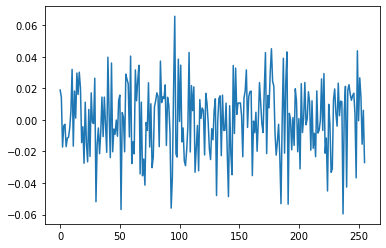

```python
plt.plot(np.mean(hamming_prediction_table-shifted_hamming_prediction_table,1))
plt.show()
```

For each column in the table you created (ie an approximate value of a key) find the correlation coefficient of the row with each of the rows of the table from the file

```python
row_dataset = []
for row in csv_reader_data:
    row_dataset.append([int(c) for c in row[2:]])
```

### Try #1

Accoirding to Chipwhisperer V4:Tutorial B6 Breaking AES (Manual CPA Attack) Breaking AES (Manual CPA Attack))

```python
def calculate_by_Chipwhisperer(row_dataset,hamming_prediction_table,traces_bound,numtraces):
    dataset = np.array(row_dataset)
    result = np.zeros((len(traces_bound),256,numtraces))
    for j,D in enumerate(traces_bound):
        print(f"#Traces = {D}")
        trace = dataset[:D,:]
        meanT = np.mean(trace,axis=0, dtype=np.float64)
        sumnum = np.zeros(numtraces)
        sumden1 = np.zeros(numtraces)
        sumden2 = np.zeros(numtraces)
        for kguess in range(256):
            hyp = hamming_prediction_table[kguess,:D]
            meanH = np.mean(hyp, dtype=np.float64)
            for i in range(D):
                hdiff = (hyp[i] - meanH)
                tdiff = (trace[i,:] - meanT)
                sumnum = sumnum + (hdiff*tdiff)
                sumden1 = sumden1 + hdiff*hdiff
                sumden2 = sumden2 + tdiff*tdiff
            result[j][kguess] = sumnum / np.sqrt( sumden1 * sumden2 )
    return result
```

```python
basic_result = calculate_by_Chipwhisperer(row_dataset,shifted_hamming_prediction_table,number_of_traces_list,N)
```

```
#Traces = 10
#Traces = 100
#Traces = 500
#Traces = 1000
#Traces = 2000
#Traces = 4000
#Traces = 8000
```

```python
def Display_CPA_Result(cpa_result,traces_bound):
    for j,d in enumerate(traces_bound):
        display(Markdown(f'#### The correlations result for {d} traces'))
        cpaoutput = np.array(cpa_result[j]).transpose()
        display(Markdown(f'The correlations X Samples for **{d}** traces'))
        plt.plot(cpaoutput)
        plt.show()
        display(Markdown(f'Highest sampling point for **{d}** traces'))
        maC = np.max(np.abs(cpaoutput.transpose()),1)
        plt.plot(maC)
        plt.show()
        display(Markdown(f'Best Key Guess for **{d}** traces'))
        display(Markdown(f'**{hex(np.argmax(maC))}**'))
    display(Markdown('#### summary of results'))
    display(Markdown('Here each row indicates the use of an increasing number of traces and in each box we indicate the correlation value between the approximate key and the measurements'))
    max_rows = np.max(np.abs(cpa_result),2)
    display(pd.DataFrame(max_rows))
    display(Markdown('Visually'))
    plt.plot(max_rows)
    plt.show()
```

The correlations result for 10 traces

The correlations X Samples for **10** traces

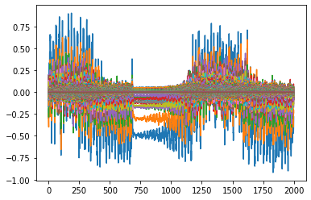

Highest sampling point for **10** traces

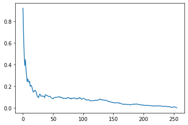

Best Key Guess for **10** traces

**0x0**

The correlations result for 100 traces

The correlations X Samples for **100** traces

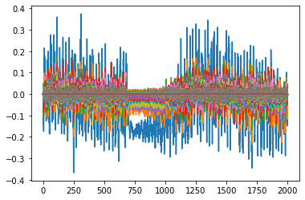

Highest sampling point for **100** traces

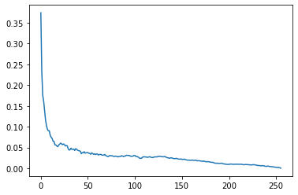

Best Key Guess for **100** traces

**0x0**

The correlations result for 500 traces

The correlations X Samples for **500** traces

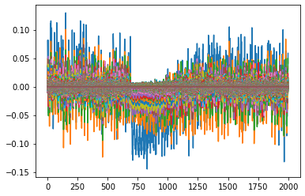

Highest sampling point for **500** traces

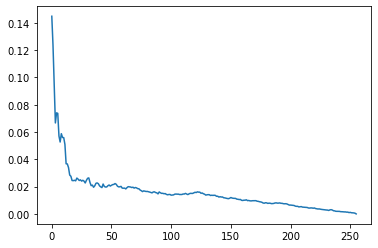

Best Key Guess for **500** traces

**0x0**

The correlations result for 1000 traces

The correlations X Samples for **1000** traces

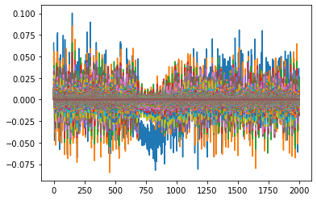

Highest sampling point for **1000** traces

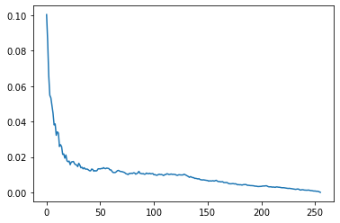

Best Key Guess for **1000** traces

**0x0**

The correlations result for 2000 traces

The correlations X Samples for **2000** traces

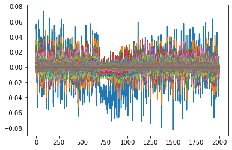

Highest sampling point for **2000** traces

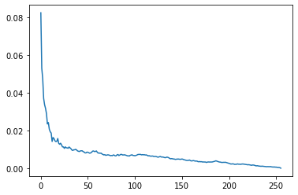

Best Key Guess for **2000** traces

**0x0**

The correlations result for 4000 traces

The correlations X Samples for **4000** traces

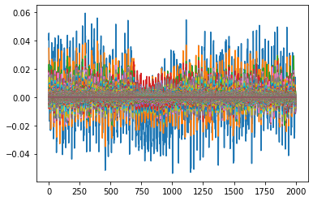

Highest sampling point for **4000** traces

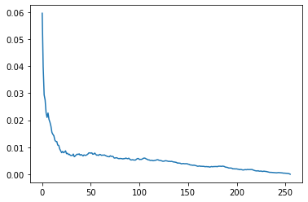

Best Key Guess for **4000** traces

**0x0**

The correlations result for 8000 traces

The correlations X Samples for **8000** traces

[3 more figures not shown]

```python
Display_CPA_Result(basic_result,number_of_traces_list)
```

In conclusion, we can see that the key 0x0 is repeated in all the results, so we can assume that it is the appropriate key for encryption.

In addition, as the number of traces increases we can see that there are fewer and fewer peaks in the graph correlations to Samples, and of course the correlation decreases.

### Try #2

```python
shifted_result = calculate_by_Chipwhisperer(row_dataset,hamming_prediction_table,number_of_traces_list,N)
```

```
#Traces = 10
#Traces = 100
#Traces = 500
#Traces = 1000
#Traces = 2000
#Traces = 4000
#Traces = 8000
```

The correlations result for 10 traces

The correlations X Samples for **10** traces

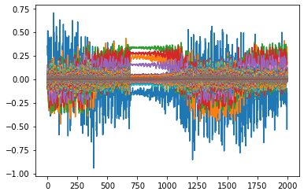

Highest sampling point for **10** traces

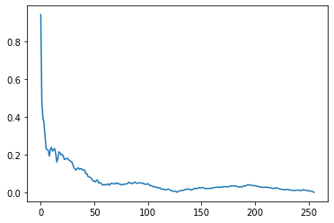

Best Key Guess for **10** traces

**0x0**

The correlations result for 100 traces

The correlations X Samples for **100** traces

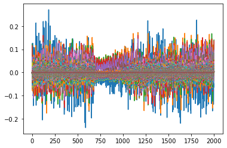

Highest sampling point for **100** traces

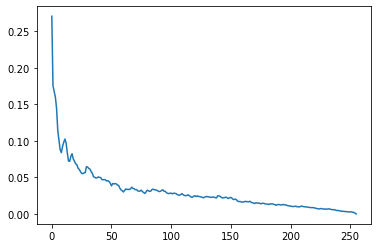

Best Key Guess for **100** traces

**0x0**

The correlations result for 500 traces

The correlations X Samples for **500** traces

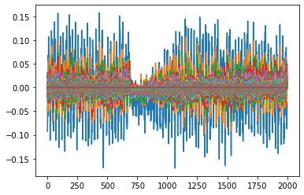

Highest sampling point for **500** traces

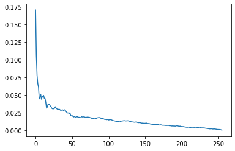

Best Key Guess for **500** traces

**0x0**

The correlations result for 1000 traces

The correlations X Samples for **1000** traces

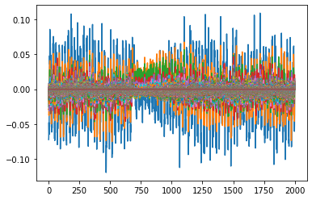

Highest sampling point for **1000** traces

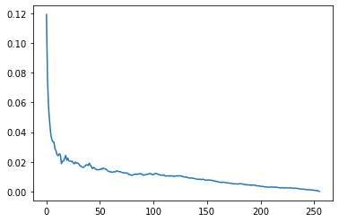

Best Key Guess for **1000** traces

**0x0**

The correlations result for 2000 traces

The correlations X Samples for **2000** traces

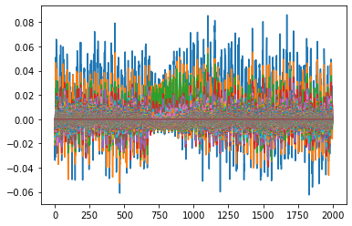

Highest sampling point for **2000** traces

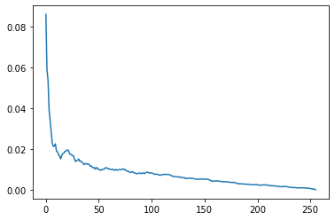

Best Key Guess for **2000** traces

**0x0**

The correlations result for 4000 traces

The correlations X Samples for **4000** traces

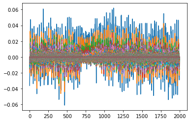

Highest sampling point for **4000** traces

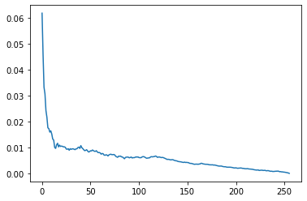

Best Key Guess for **4000** traces

**0x0**

The correlations result for 8000 traces

The correlations X Samples for **8000** traces

[3 more figures not shown]

```python
Display_CPA_Result(shifted_result,number_of_traces_list)
```

To summarize the results of this experience, and of the previous experience. We can conclude that the action of shift rows does not significantly affect the correlation and therefore we can ignore it

### Try #3

We implemented the algorithm 10.3 according to the Hardware security book- Design, Threats, and Safeguards. The results of the run can be seen here

```python
meanTrace = []
dataset = np.array(row_dataset).transpose()
book_result = np.zeros((256,len(dataset)))
meanH = np.mean(hamming_prediction_table,1)
for i in range(len(dataset)):
    meanTrace.append(np.average(dataset[i]))
```

```python
print_every = 10
if os.path.exists(CPA_Book_Result_PATH):
    with open(CPA_Book_Result_PATH,"r") as fp:
        for i,line in enumerate(fp):
            if i % print_every == 0:
                print(f"Proccesing {hex(i)}")
            book_result[i] = line.split()
else:
    with open(CPA_Book_Result_PATH,"w") as fp:
        for i in range(0,256,1):
            if i % print_every == 0:
                print(f"Proccesing {hex(i)}")
            for j in range(len(csv_reader_data[0])-2):
                a = 0
                b = 0
                c = 0
                for k in range(len(csv_reader_data)):
                    temph = (hamming_prediction_table[i][k] - meanH[i])
                    tempt = (int(csv_reader_data[k][j+2]) - meanTrace[j])
                    a += temph*tempt
                    b += temph*temph
                    c += tempt*tempt
                book_result[i][j] = (a / np.sqrt(b*c))
            fp.write(' '.join(map(str, book_result[i])) + "\n")
```

```
Proccesing 0x0
Proccesing 0xa
Proccesing 0x14
Proccesing 0x1e
Proccesing 0x28
Proccesing 0x32
Proccesing 0x3c
Proccesing 0x46
Proccesing 0x50
Proccesing 0x5a
Proccesing 0x64
Proccesing 0x6e
Proccesing 0x78
Proccesing 0x82
Proccesing 0x8c
Proccesing 0x96
Proccesing 0xa0
Proccesing 0xaa
Proccesing 0xb4
Proccesing 0xbe
Proccesing 0xc8
Proccesing 0xd2
Proccesing 0xdc
Proccesing 0xe6
Proccesing 0xf0
Proccesing 0xfa
```

The results according to the Hardware security book

|  | 0 | 1 | 2 | 3 | 4 | 5 | 6 | 7 | 8 | 9 | ... | 246 | 247 | 248 | 249 | 250 | 251 | 252 | 253 | 254 | 255 |
| --- | --- | --- | --- | --- | --- | --- | --- | --- | --- | --- | --- | --- | --- | --- | --- | --- | --- | --- | --- | --- | --- |
| 0 | -0.002015 | -0.000658 | 0.000577 | -0.003722 | -0.003822 | -0.000117 | 0.002732 | -0.000252 | -0.001967 | -0.001502 | ... | -0.000087 | 0.000797 | -0.000928 | -0.000626 | 0.001525 | 0.002409 | -0.001323 | -0.001272 | 0.001081 | -0.000857 |
| 1 | -0.002042 | 0.001057 | -0.000030 | -0.002827 | -0.004189 | 0.001854 | 0.001963 | -0.000010 | -0.000132 | -0.000273 | ... | 0.001593 | -0.000153 | -0.000732 | -0.001557 | -0.000148 | 0.001678 | -0.003090 | 0.000268 | 0.003192 | -0.003211 |
| 2 | -0.002850 | 0.001225 | 0.000597 | -0.002934 | -0.003099 | 0.001702 | 0.003460 | 0.001638 | 0.000448 | -0.001426 | ... | 0.000587 | 0.000849 | 0.000091 | -0.002241 | 0.002122 | 0.002070 | -0.001669 | 0.000765 | 0.002532 | -0.002641 |
| 3 | -0.001330 | -0.000088 | 0.000573 | -0.002495 | -0.002155 | 0.000964 | 0.002503 | 0.001319 | -0.001703 | 0.000054 | ... | -0.000430 | 0.001254 | -0.000413 | -0.002476 | -0.000385 | 0.004744 | -0.000154 | 0.001444 | 0.001914 | -0.003408 |
| 4 | -0.000527 | -0.000904 | -0.001242 | -0.001440 | -0.002032 | 0.001221 | -0.000054 | 0.002112 | -0.003566 | -0.001312 | ... | 0.000053 | 0.001615 | 0.001990 | -0.003097 | -0.000797 | 0.003941 | 0.002648 | 0.001907 | 0.001762 | -0.003364 |
| ... | ... | ... | ... | ... | ... | ... | ... | ... | ... | ... | ... | ... | ... | ... | ... | ... | ... | ... | ... | ... | ... |
| 1995 | -0.000314 | -0.003216 | 0.001247 | 0.000781 | -0.003308 | 0.000475 | 0.005865 | -0.000204 | 0.003561 | -0.003290 | ... | 0.000076 | -0.002891 | -0.000335 | 0.001759 | 0.002945 | -0.001035 | -0.000993 | -0.000813 | 0.001499 | 0.001346 |
| 1996 | -0.000887 | -0.003509 | -0.000501 | 0.002055 | -0.000599 | -0.001159 | 0.004651 | 0.000353 | 0.001607 | -0.001128 | ... | -0.000858 | -0.001618 | 0.000451 | 0.001899 | 0.003057 | 0.000226 | -0.003133 | -0.003578 | 0.000579 | 0.001832 |
| 1997 | 0.001323 | -0.004125 | 0.000843 | -0.002753 | -0.000964 | -0.000653 | 0.003378 | 0.002280 | 0.000496 | -0.002860 | ... | 0.001796 | 0.000622 | 0.000526 | 0.001286 | 0.002343 | 0.000572 | -0.002567 | -0.002862 | 0.002372 | 0.000958 |
| 1998 | -0.001571 | -0.001685 | -0.000415 | -0.000701 | -0.001797 | 0.000431 | 0.003271 | 0.000316 | -0.000359 | 0.001735 | ... | 0.000461 | -0.000930 | -0.001803 | 0.001666 | -0.000020 | 0.000794 | -0.003828 | -0.001020 | 0.003189 | 0.000352 |
| 1999 | -0.001521 | -0.001500 | 0.003087 | -0.002433 | -0.000822 | -0.000003 | 0.003496 | -0.002098 | -0.001943 | -0.000957 | ... | 0.000208 | 0.000207 | -0.000130 | 0.000281 | 0.001341 | -0.000224 | -0.000508 | -0.000864 | 0.002914 | -0.000850 |

2000 rows × 256 columns

correlations X Samples

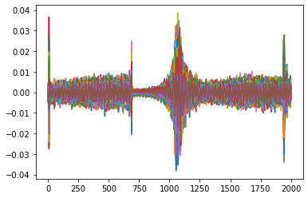

Highest sampling point

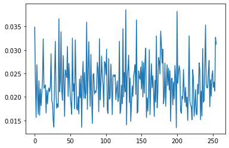

Best Key Guess **0x80**

```python
display(Markdown(f'#### The results according to the Hardware security book'))
cpaoutput = np.array(book_result).transpose()
display(pd.DataFrame(cpaoutput))
display(Markdown(f'correlations X Samples'))
plt.plot(cpaoutput)
plt.show()
display(Markdown(f'Highest sampling point '))
maC = np.max(np.abs(cpaoutput.transpose()),1)
plt.plot(maC)
plt.show()
display(Markdown(f'Best Key Guess **{hex(np.argmax(maC))}**'))
```

From the results of this experiment, it can be seen that the graph of correlation for samples is much more focused (it has much fewer peaks) but on the other hand we do not see a clear picture for the maximum correlation line